# Data Acquisition and Management (2)

MPA 6020 (Spring 2016)

22 February, 2016

# Aggregating Data and Other Operations

Generating aggregated data frames is frequently used in analysis. I’ll demonstrated some operations with the `dplyr` package. This is not the only package capable of performing the operations shown below but it is one (if not *the*) fastest. We’ll use a particular data set to show what `dplyr` can do – the **nycflights13** data frame that contains all 336776 flights that departed from New York City in 2013 (source: [US Bureau of Transportation Statistics](http://www.transtats.bts.gov/DatabaseInfo.asp?DB_ID=120&Link=0)).

```r
library(nycflights13)
library(dplyr)
head(flights)
```

| year | month | day | dep_time | dep_delay | arr_time | arr_delay | carrier | tailnum | flight | origin | dest | air_time | distance | hour | minute |
| --- | --- | --- | --- | --- | --- | --- | --- | --- | --- | --- | --- | --- | --- | --- | --- |
| 2013 | 1 | 1 | 517 | 2 | 830 | 11 | UA | N14228 | 1545 | EWR | IAH | 227 | 1400 | 5 | 17 |
| 2013 | 1 | 1 | 533 | 4 | 850 | 20 | UA | N24211 | 1714 | LGA | IAH | 227 | 1416 | 5 | 33 |
| 2013 | 1 | 1 | 542 | 2 | 923 | 33 | AA | N619AA | 1141 | JFK | MIA | 160 | 1089 | 5 | 42 |
| 2013 | 1 | 1 | 544 | -1 | 1004 | -18 | B6 | N804JB | 725 | JFK | BQN | 183 | 1576 | 5 | 44 |
| 2013 | 1 | 1 | 554 | -6 | 812 | -25 | DL | N668DN | 461 | LGA | ATL | 116 | 762 | 5 | 54 |
| 2013 | 1 | 1 | 554 | -4 | 740 | 12 | UA | N39463 | 1696 | EWR | ORD | 150 | 719 | 5 | 54 |

`filter()` allows you to subset the data. In the code below we are asking for all flights on January 1 (i.e., with `month == 1, day == 1`). The other ways of subsetting the data are also shown below.

```r
filter(flights, month == 1, day == 1)
flights[flights$month == 1 & flights$day == 1, ]
subset(flights, month == 1 & day == 1)
```

Let us now sort the data frame, first by year, month and day, and then by arrival delay (**arr_delay**).

```r
arrange(flights, year, month, day)
arrange(flights, arr_delay)
arrange(flights, desc(arr_delay))
```

Note the difference between `arr_delay` and `desc(arr_delay)`.

We can select columns by name in several ways:

```r
select(flights, year, month, day)
select(flights, year:day)
select(flights, -c(year, month, day))
select(flights, -(year:day))
```

Note that `year, month, day` is the same as `year:day`. Note too that we can ask for some columns to be excluded by running `-c(year, month, day)` … which is the same as `-(year:day)`.

If we want to rename some columns we can do so via `rename()`.

```r
rename(flights, arrival.delay = arr_delay)
rename(flights, arrival.time = arr_time, departure.time = dep_time)
```

Unique values in a column can be extracted as well. For example, how many unique aircraft do we have flagged by the tail number (**tailnum**)? This is extracted by `distinct(select())`, both for a single column (as in *tailnum*) and for combinations of multiple columns (as in *origin, des*).

```r
distinct(select(flights, tailnum))
distinct(select(flights, origin, dest))
```

If we want to calculate something based on existing columns and then add these new calculated values to the data frame, `mutate` comes in handy.

```r
flights = mutate(flights, gain = arr_delay - dep_delay)
```

If you look at the data frame you will see that **gain** has been added as the $17^{th}$ column. Now, one of the amazing things about the `mutate` command is that it allows you to refer to a previous calculation within the same command (see below);

```r
flights = mutate(flights, gain = arr_delay - dep_delay, gain_per_hour = gain/(air_time/60))
```

Note that **gain_per_hour** has been added by dividing **gain** by (**air_time / 60**) … since longer flights can gain more time than shorter flights.

`summarise()` is another useful function (see below).

```r
tab.1 = summarise(flights, mean_arr_delay = mean(arr_delay, na.rm = TRUE),
    sd_arr_delay = sd(arr_delay, na.rm = TRUE), mean_dep_delay = mean(dep_delay,
        na.rm = TRUE), sd_dep_delay = sd(dep_delay, na.rm = TRUE))

library(knitr)
kable(tab.1, caption = "Mean and Standard Deviation of Arrival and Departure Delays ")
```

Mean and Standard Deviation of Arrival and Departure Delays

| mean_arr_delay | sd_arr_delay | mean_dep_delay | sd_dep_delay |
| --- | --- | --- | --- |
| 6.895377 | 44.63329 | 12.63907 | 40.21006 |

You can draw random samples from your data frame as well. The code below shows a random sub-sample of 15 observations and a random sub-sample of 2% of the full data.

```r
sample_n(flights, 15)
sample_frac(flights, 0.02)
```

So far we have been running these commands on all observations rather than by some group indicator. For example, what if we wanted to run some calculations for each unique aircraft (identified by__tailnum__)? The first thing we will do is create the grouping key **by_tailnum** via the `group_by()` command.

```r
by_tailnum = group_by(flights, tailnum)
delay = summarise(by_tailnum, count = n(), dist = mean(distance,
    na.rm = TRUE), delay = mean(arr_delay, na.rm = TRUE))
```

If you look at **delay** you will see 4044 observations of 4 variables – **count** tells you how many times each aircraft has arrived at NYC, **dist** tells you the average distance flown, and **delay** tells you the average arrival delay. Now, is the average delay related to the average distance flown? We’ll ask and answer this question via a simple scatter-plot on a subset of the **delay** data frame, subset in that the aircraft must have more than 20 arrivals in NYC and flown average distance of less than 2000 miles.

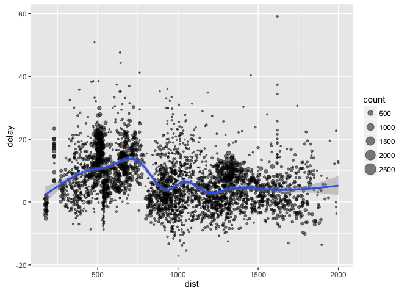

```r
library(plotly)
library(ggplot2)
delay <- filter(delay, count > 20, dist < 2000)
p = ggplot(delay, aes(x = dist, y = delay)) + geom_point(aes(size = count),
    alpha = 0.5) + geom_smooth() + scale_size_area()
p
```

What if we wanted to know the number of flights to each destination listed in the data frame?

```r
destinations = group_by(flights, dest)
summarise(destinations, flights = n())
```

What about the number of flights to each destination by month?

```r
destinations = group_by(flights, month, dest)
summarise(destinations, flights = n())
```

Note that now you have an extra column (**month**) because you asked for the number of flights to each destination *for each month*.

```r
destinations = group_by(flights, day, dest)
flights_per_day = summarise(destinations, flights = n())

flights_per_month = summarise(flights_per_day, flights = sum(flights))

flights_per_year = summarise(flights_per_month, flights = sum(flights))
```